## Description of protein quantification errors in “An integrated multi-omics analysis of the NK603 Roundup-tolerant GM maize reveals metabolism disturbances caused by the transformation process”

##### Claire D. McWhite* and Daniel R. Boutz

##### The University of Texas at Austin, Austin TX, USA

##### *Correspondence: claire.mcwhite@utexas.edu

This document describes specific errors in protein quantification in the paper “An integrated multi-omics analysis of the NK603 Roundup-tolerant GM maize reveals metabolism disturbances caused by the transformation process” (Mesnage, 2016).

### Claims of measuring protein expression differences

The text of Mesnage, 2016 clearly states that proteins were quantified.

- “Changes in proteins and metabolites…”
- “we have performed proteomics and metabolomics analyses of NK603 (sprayed or unsprayed with Roundup) and isogenic maize kernels (Fig. 1). We used a TMT10plex isobaric mass tag labelling method and quantified proteins by Liquid chromatography-tandem mass spectrometry (LC-MS/MS)”
- “Overall, the MCIA shows that the GM transformation process was the major contributor to variation in the protein and metabolite profiles…”
- “The list of proteins and metabolites having their levels significantly disturbed is given in Additional files 5 and 6, respectively.”
- “While only one protein is newly produced as a result of the transgene insertion, a total of 117 proteins and 91 metabolites have been altered in maize by the genetic transformation process”
- “One protein (B4G0K5) and 31 metabolites had their expression significantly altered…”
- “Among them, pyruvate kinase (B4F9G8), enolase (ENO1), and three glyceraldehyde-3-phosphate dehydrogenases (GAPC1, GAPC2, GAPC3) had their levels increased in NK603 maize.”
- “Additionally, while proteins associated with glycolysis were overexpressed…”

### Presented results are peptide fold changes, not protein fold changes.

While the text claims that proteins were quantified, in fact, peptides were quantified. Supplementary Dataset 5 of Mesnage, 2016 contains the main quantitative results of the study, and is described as a “List of proteins having their level significantly altered”. Our analysis uses the tab ‘isogenic x nk603 + R’ of this dataset as a demonstration, however our findings apply equally to tab ‘isogenic x nk603’.

The fold changes from this file for the control vs. Roundup-Ready strain nk603+Roundup comparison are plotted in Figure 1. We found that these fold changes actually correspond to fold changes of peptides (Figure 1). If any one peptide from a protein passes a threshold, the entire protein is counted as enriched.

Multiple proteins described as enriched/depleted between samples have individual peptides with either positive and negative fold changes. For example, the protein Q7M1Z8 has 4 entries in Supplementary Dataset 5 ‘isogenic x nk603 + R’, reproduced exactly in Table 1 below. These four peptides counts as four of 156 proteins described as perturbed in sprayed NK603 maize“. Six of these 156 disturbed proteins are actually single peptides of Glyceraldehyde-3-phosphate dehydrogenase. Conventionally, each protein would have only one fold change measurement, as a single protein can only be enriched, unchanged, or depleted across two conditions.

[interactive chart not shown]

*Figure 1. Each fold change described between control and Roundup-treated Roundup ready maize in Supplementary Dataset 5 ‘isogenic x nk603 + R’ of Mesnage, 2016 is the fold change of an individual peptide. Vertical lines connect peptides from the same protein, showing many cases with contradictory fold changes. Opposite fold changes of peptides from the protein Q7M1Z8 are highlighted in red. Most proteins plotted also have additional peptides that would fall in the gray zone and are not observed differentially, demonstrated in Figure 2.*

Table 1. One example from Supplementary Dataset 5 of the same protein showing both positive and negative fold change

| Uniprot ID | Protein name | Mass (Da) | Log2 FC | P-adjusted values |
| --- | --- | --- | --- | --- |
| Q7M1Z8 | OS=Zea mays GN=Zm.3896 | 395.48 | 2.0333 | 0.0307 |
| Q7M1Z8 | OS=Zea mays GN=Zm.3896 | 661.31 | 1.0405 | 0.0423 |
| Q7M1Z8 | OS=Zea mays GN=Zm.3896 | 722.35 | -0.5861 | 0.0247 |
| Q7M1Z8 | OS=Zea mays GN=Zm.3896 | 823.46 | -0.9408 | 0.0001 |

### Analysis of other peptides from proteins described as perturbed.

Though Supplementary Dataset 5 only shows peptides with a log2 fold change above cutoffs (-0.5, +0.5), the peptide quantification data provided to us by Mesnage and Antoniou show that multiple peptides from the same proteins described as perturbed fall below this cutoff (Figure 2). The protein Q7M1Z8 (discussed above) has an additional 30 quantifiable peptides, suggesting that the 4 peptides with above-threshold fold changes are false positives (Table 1, Figure 1). In another case, there are 4 peptide fold changes from P15590, while there are measurements for 48 P15590 peptides in the peptide quantification data. We found that 24 of the 105 protein identifiers described as perturbed in ‘isogenic x nk603 + R’ only have evidence from a single peptide in the peptide quantification data. Most other proteins have multiple other peptides whose fold changes must have fallen below the thresholds. The presence of many other peptides below threshold strongly suggests that many of these proteins would not show enrichment if all their peptide measurements were integrated to calculate a protein fold change, and listed enriched peptides are likely false positives or outliers.

[interactive chart not shown]

*Figure 2. Many more quantifiable peptides for proteins flagged as differentially expressed are present in the peptide quantification data than in Supplementary Dataset 5, suggesting that many peptides for these proteins are not different across conditions. Proteins largely seem to be flagged as differentially expressed based on outlier peptides or single peptide observations. Differential expression determination is based on a single peptide to the left of the dotted line. Proteins to the right of the dotted line have multiple quantifiable peptides not included in the fold change calculation.*

The use of individual peptide fold changes instead of protein fold changes to obtain lists of proteins significant affects the conclusions in this paper. To highlight one example, the abstract states that “Changes in proteins and metabolites of glutathione metabolism were indicative of increased oxidative stress.”. The text describe three proteins as altered to support this oxidative stress conclusion: “The comparison between Roundup-sprayed NK603 and control samples revealed a similar pattern to that observed in unsprayed samples. However, glutathione metabolism (KEGG ID 480) showed a significant alteration in sprayed NK603. The proteins assigned to that pathway, glutathione S-transferase 1 and 6-phosphogluconate dehydrogenase (P12653 and B4FSV6 respectively) were more abundant in sprayed samples while another glutathione transferase isoform GST-5 (A0A0B4J3E6) was less abundant.”

The peptide evidence for these three proteins (Figure 3) shows that conclusions about A0A0B4J3E6 and P12653 are based on single peptides. B4FSV6 has three other peptides with fold enrichments below threshold, suggesting that the full protein may not show changes across conditions. Differential expression of these proteins is not supported by the data.

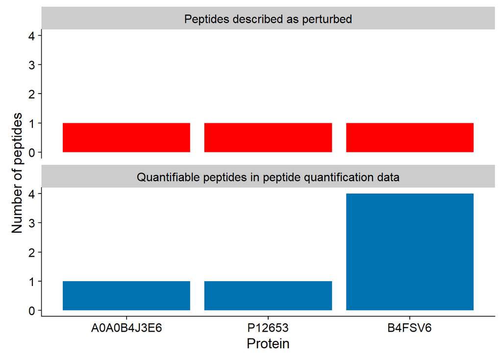

*Figure 3. Specific proteins described as having altered expression in the text are poorly supported by the proteomics data. Proteins A0A0B4J3E6 and P12653 are based on single peptide observations, while most B4FSV6 peptides are not found differentially. Subset of Figure 2 data*

### Further demonstration that fold change values in Supplementary Dataset 5 described as protein fold changes correspond directly to the peptide fold changes

The first few rows of Supplementary Dataset 5 ‘isogenic x nk603 + R’ 2015 are reproduced in Table 2. Notably:

1. The top differential peptide between the control strain and the Roundup Ready strain is identified as a fungal tubulin, not a maize protein.
2. The values given in the column ‘Mass (Da)’ do not correspond to the masses of the full proteins (Table 3). Full proteins have masses in the 10’s of thousands of Daltons. Instead, the values in the ‘Mass (Da)’ column correspond to the Mass to Charge ratio in the peptide TMT file (Table 4), a value calculated from mass and charge state of an indidual spectrum.

Table 2. First few rows of Supplementary Dataset 5

| UniProt ID | Protein name | Mass (Da) | Log2 FC | P-adjusted values |
| --- | --- | --- | --- | --- |
| W7LNM5 | Tubulin alpha chain OS=Gibberella moniliformis (strain M3125 / FGSC 7600) GN=FVEG_00855 | 626.81 | -3.7702 | 0.0011 |
| B6SIZ2 | Oleosin OS=Zea mays GN=LOC100280642 | 401.21 | -3.0929 | 0.0019 |
| Q41784 | Tubulin beta-7 chain OS=Zea mays GN=TUBB7 | 761.09 | -3.0487 | 0.0058 |

Table 3. Actual protein masses are two orders of magnitude larger than the masses in Supplementary Dataset 5

| UniProt ID | Mass (Da) |
| --- | --- |
| W7LNM5 | 50378.66 |
| B6SIZ2 | 18332.85 |
| Q41784 | 50094.36 |

Table 4. Proteins described as having significant fold changes in Supplementary Dataset 5 are actually peptides, matching individual peptides in the peptide quantification file. Mass to Charge Ratio (m/z) is mislabeled as Mass (Da)

| Peptide | UniProt ID | Modifications | m/z | charge state |
| --- | --- | --- | --- | --- |
| eDAANNYAR | W7LNM5 | N-Term(TMT6plex) | 626.81 | 2 |
| tPDYVEEAHRR | B6SIZ2 | N-Term(TMT6plex) | 401.21 | 2 |
| eILHIQGGQcGNQIGAk | Q41784 | N-Term(TMT6plex); C10(Carbamidomethyl); K17(TMT6plex) | 761.09 | 2 |

### Protein inference

Results contain repeats of peptides with isoleucine/leucine mass ambiguity, as well as non-unique peptides that are common to many proteins. As an example, the protein B4FUK7 is listed twice in Supplementary Dataset 5 ‘isogenic x nk603 + R’ based on a single peptide (Table 5). These entries both contribute to the count of 156 differentially expressed proteins, and derive from one observation of the peptide vTGEA(I/L)k. This short peptide additionally matches six different proteins, raising the question of how multiply matched peptides were assigned to single proteins.

Table 5. Entries for B4FUK7 in Supplementary Dataset 5 based on the observation of the peptide vTGEA(I/L)k. According to the peptide quantification data, this peptide matches six distinct proteins, but is assigned to only B4FUK7 in the final results

| UniProt ID | Protein name | Mass (Da) | Log2 FC | P-adjusted values | Peptide | Protein Matches |
| --- | --- | --- | --- | --- | --- | --- |
| B4FUK7 | Uncharacterized protein OS=Zea mays GN=LOC100275372 | 588.4 | 0.9871 | 0.0479 | vTGEALk | B4FUK7;B6SS31;B4G0K5;B4F9U9;C4J722;C0PGD3 |
| B4FUK7 | Uncharacterized protein OS=Zea mays GN=LOC100275372 | 588.4 | 0.9871 | 0.0479 | vTGEAIk | B4FUK7;B6SS31;B4G0K5;B4F9U9;C4J722;C0PGD3 |

### Conclusion

We found that peptides, not proteins, are quantified in this paper, and that this error likely introduces false positives in measuring differential protein expression. This same analysis approach was used in another recent paper by the same lead authors in Scientific Reports, “Multiomics reveal non-alcoholic fatty liver disease in rats following chronic exposure to an ultra-low dose of Roundup herbicide” (Mesnage, 2017). Both papers incorrectly use peptide fold changes as a proxy for full protein differences, and therefore their conclusions are not reliable.

##### Conflict of Interest Statement

Neither CDM nor DRB declare conflicts of interest

##### References

[1] https://www.nature.com/articles/srep37855 “An integrated multi-omics analysis of the NK603 Roundup-tolerant GM maize reveals metabolism disturbances caused by the transformation process”, Robin Mesnage, Sarah Z. Agapito-Tenfen, Vinicius Vilperte, George Renney, Malcolm Ward, Gilles-Eric SÃ©ralini, Rubens O. Nodari & Michael N. Antoniou, Scientific Reports 6, Article number: 37855 (2016), doi:10.1038/srep37855

[6] https://www.nature.com/articles/srep39328 “Multiomics reveal non-alcoholic fatty liver disease in rats following chronic exposure to an ultra-low dose of Roundup herbicide”, Robin Mesnage, George Renney, Gilles-Eric SÃ©ralini, Malcolm Ward & Michael N. Antoniou, Scientific Reports 7, Article number: 39328 (2017), doi:10.1038/srep39328